# Risk Factor Analysis

## Outcome Variable

**Outcome Variable:** ever_stunted

## Predictor Variables

**Intervention Variable:** hhwealth_quart

**Adjustment Set:**

unadjusted

## Stratifying Variables

The analysis was stratified on these variable(s):

- agecat
- studyid

The following strata were considered:

- agecat: 12 months, studyid: ki1000108-CMC-V-BCS-2002
- agecat: 12 months, studyid: ki1000108-IRC
- agecat: 12 months, studyid: ki1066203-TanzaniaChild2
- agecat: 12 months, studyid: ki1113344-GMS-Nepal
- agecat: 12 months, studyid: ki1114097-CONTENT
- agecat: 12 months, studyid: ki1148112-LCNI-5
- agecat: 12 months, studyid: kiGH5241-JiVitA-3
- agecat: 12 months, studyid: kiGH5241-JiVitA-4
- agecat: 18 months, studyid: ki1000108-CMC-V-BCS-2002
- agecat: 18 months, studyid: ki1000108-IRC
- agecat: 18 months, studyid: ki1066203-TanzaniaChild2
- agecat: 18 months, studyid: ki1113344-GMS-Nepal
- agecat: 18 months, studyid: ki1114097-CONTENT
- agecat: 18 months, studyid: ki1148112-LCNI-5
- agecat: 18 months, studyid: kiGH5241-JiVitA-3
- agecat: 18 months, studyid: kiGH5241-JiVitA-4
- agecat: 24 months, studyid: ki1000108-CMC-V-BCS-2002
- agecat: 24 months, studyid: ki1000108-IRC
- agecat: 24 months, studyid: ki1066203-TanzaniaChild2
- agecat: 24 months, studyid: ki1113344-GMS-Nepal
- agecat: 24 months, studyid: ki1114097-CONTENT
- agecat: 24 months, studyid: ki1148112-LCNI-5
- agecat: 24 months, studyid: kiGH5241-JiVitA-3
- agecat: 24 months, studyid: kiGH5241-JiVitA-4
- agecat: 3 months, studyid: ki1000108-CMC-V-BCS-2002
- agecat: 3 months, studyid: ki1000108-IRC
- agecat: 3 months, studyid: ki1066203-TanzaniaChild2
- agecat: 3 months, studyid: ki1113344-GMS-Nepal
- agecat: 3 months, studyid: ki1114097-CONTENT
- agecat: 3 months, studyid: kiGH5241-JiVitA-3
- agecat: 3 months, studyid: kiGH5241-JiVitA-4
- agecat: 6 months, studyid: ki1000108-CMC-V-BCS-2002
- agecat: 6 months, studyid: ki1000108-IRC
- agecat: 6 months, studyid: ki1066203-TanzaniaChild2
- agecat: 6 months, studyid: ki1113344-GMS-Nepal
- agecat: 6 months, studyid: ki1114097-CONTENT
- agecat: 6 months, studyid: ki1148112-LCNI-5
- agecat: 6 months, studyid: kiGH5241-JiVitA-3
- agecat: 6 months, studyid: kiGH5241-JiVitA-4

## Methods Detail

# Results Detail

## Results Plots

[figure not shown]

[figure not shown]

[figure not shown]

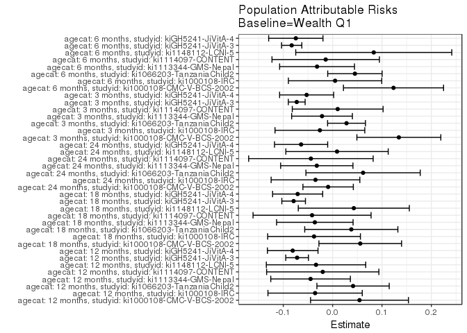

## Data Summary

| agecat | studyid | A | n | nA | nAY0 | nAY1 |
| --- | --- | --- | --- | --- | --- | --- |
| 12 months | ki1000108-CMC-V-BCS-2002 | Wealth Q1 | 372 | 90 | 32 | 58 |
| 12 months | ki1000108-CMC-V-BCS-2002 | Wealth Q2 | 372 | 95 | 27 | 68 |
| 12 months | ki1000108-CMC-V-BCS-2002 | Wealth Q3 | 372 | 91 | 32 | 59 |
| 12 months | ki1000108-CMC-V-BCS-2002 | Wealth Q4 | 372 | 96 | 21 | 75 |
| 12 months | ki1000108-IRC | Wealth Q1 | 408 | 105 | 48 | 57 |
| 12 months | ki1000108-IRC | Wealth Q2 | 408 | 101 | 43 | 58 |
| 12 months | ki1000108-IRC | Wealth Q3 | 408 | 103 | 57 | 46 |
| 12 months | ki1000108-IRC | Wealth Q4 | 408 | 99 | 53 | 46 |
| 12 months | ki1066203-TanzaniaChild2 | Wealth Q1 | 495 | 144 | 104 | 40 |
| 12 months | ki1066203-TanzaniaChild2 | Wealth Q2 | 495 | 94 | 64 | 30 |
| 12 months | ki1066203-TanzaniaChild2 | Wealth Q3 | 495 | 143 | 96 | 47 |
| 12 months | ki1066203-TanzaniaChild2 | Wealth Q4 | 495 | 114 | 73 | 41 |
| 12 months | ki1113344-GMS-Nepal | Wealth Q1 | 582 | 148 | 74 | 74 |
| 12 months | ki1113344-GMS-Nepal | Wealth Q2 | 582 | 146 | 83 | 63 |
| 12 months | ki1113344-GMS-Nepal | Wealth Q3 | 582 | 142 | 81 | 61 |
| 12 months | ki1113344-GMS-Nepal | Wealth Q4 | 582 | 146 | 79 | 67 |
| 12 months | ki1114097-CONTENT | Wealth Q1 | 215 | 59 | 43 | 16 |
| 12 months | ki1114097-CONTENT | Wealth Q2 | 215 | 52 | 39 | 13 |
| 12 months | ki1114097-CONTENT | Wealth Q3 | 215 | 52 | 39 | 13 |
| 12 months | ki1114097-CONTENT | Wealth Q4 | 215 | 52 | 40 | 12 |
| 12 months | ki1148112-LCNI-5 | Wealth Q1 | 392 | 95 | 46 | 49 |
| 12 months | ki1148112-LCNI-5 | Wealth Q2 | 392 | 93 | 49 | 44 |
| 12 months | ki1148112-LCNI-5 | Wealth Q3 | 392 | 95 | 46 | 49 |
| 12 months | ki1148112-LCNI-5 | Wealth Q4 | 392 | 109 | 62 | 47 |
| 12 months | kiGH5241-JiVitA-3 | Wealth Q1 | 8371 | 1818 | 866 | 952 |
| 12 months | kiGH5241-JiVitA-3 | Wealth Q2 | 8371 | 2061 | 1060 | 1001 |
| 12 months | kiGH5241-JiVitA-3 | Wealth Q3 | 8371 | 2106 | 1145 | 961 |
| 12 months | kiGH5241-JiVitA-3 | Wealth Q4 | 8371 | 2386 | 1519 | 867 |
| 12 months | kiGH5241-JiVitA-4 | Wealth Q1 | 1419 | 367 | 178 | 189 |
| 12 months | kiGH5241-JiVitA-4 | Wealth Q2 | 1419 | 338 | 178 | 160 |

[output cut: 130 more lines]

## Results Table

### Parameter: TSM

| agecat | studyid | intervention_level | baseline_level | estimate | ci_lower | ci_upper |
| --- | --- | --- | --- | --- | --- | --- |
| 12 months | ki1000108-CMC-V-BCS-2002 | Wealth Q1 | NA | 0.6444444 | 0.5454165 | 0.7434724 |
| 12 months | ki1000108-CMC-V-BCS-2002 | Wealth Q2 | NA | 0.7157895 | 0.6249690 | 0.8066099 |
| 12 months | ki1000108-CMC-V-BCS-2002 | Wealth Q3 | NA | 0.6483516 | 0.5501155 | 0.7465878 |
| 12 months | ki1000108-CMC-V-BCS-2002 | Wealth Q4 | NA | 0.7812500 | 0.6984432 | 0.8640568 |
| 12 months | ki1000108-IRC | Wealth Q1 | NA | 0.5428571 | 0.4474557 | 0.6382586 |
| 12 months | ki1000108-IRC | Wealth Q2 | NA | 0.5742574 | 0.4777086 | 0.6708063 |
| 12 months | ki1000108-IRC | Wealth Q3 | NA | 0.4466019 | 0.3504758 | 0.5427281 |
| 12 months | ki1000108-IRC | Wealth Q4 | NA | 0.4646465 | 0.3662805 | 0.5630125 |
| 12 months | ki1066203-TanzaniaChild2 | Wealth Q1 | NA | 0.2777778 | 0.2045476 | 0.3510080 |
| 12 months | ki1066203-TanzaniaChild2 | Wealth Q2 | NA | 0.3191489 | 0.2248198 | 0.4134781 |
| 12 months | ki1066203-TanzaniaChild2 | Wealth Q3 | NA | 0.3286713 | 0.2516045 | 0.4057382 |
| 12 months | ki1066203-TanzaniaChild2 | Wealth Q4 | NA | 0.3596491 | 0.2714664 | 0.4478318 |
| 12 months | ki1113344-GMS-Nepal | Wealth Q1 | NA | 0.5000000 | 0.4193767 | 0.5806233 |
| 12 months | ki1113344-GMS-Nepal | Wealth Q2 | NA | 0.4315069 | 0.3510984 | 0.5119153 |
| 12 months | ki1113344-GMS-Nepal | Wealth Q3 | NA | 0.4295775 | 0.3480889 | 0.5110660 |
| 12 months | ki1113344-GMS-Nepal | Wealth Q4 | NA | 0.4589041 | 0.3780051 | 0.5398031 |
| 12 months | ki1114097-CONTENT | Wealth Q1 | NA | 0.2711864 | 0.1574822 | 0.3848907 |
| 12 months | ki1114097-CONTENT | Wealth Q2 | NA | 0.2500000 | 0.1320333 | 0.3679667 |
| 12 months | ki1114097-CONTENT | Wealth Q3 | NA | 0.2500000 | 0.1320333 | 0.3679667 |
| 12 months | ki1114097-CONTENT | Wealth Q4 | NA | 0.2307692 | 0.1159866 | 0.3455518 |
| 12 months | ki1148112-LCNI-5 | Wealth Q1 | NA | 0.5157895 | 0.4151672 | 0.6164118 |
| 12 months | ki1148112-LCNI-5 | Wealth Q2 | NA | 0.4731183 | 0.3715162 | 0.5747204 |
| 12 months | ki1148112-LCNI-5 | Wealth Q3 | NA | 0.5157895 | 0.4151672 | 0.6164118 |
| 12 months | ki1148112-LCNI-5 | Wealth Q4 | NA | 0.4311927 | 0.3381016 | 0.5242837 |
| 12 months | kiGH5241-JiVitA-3 | Wealth Q1 | NA | 0.5236524 | 0.5006930 | 0.5466118 |
| 12 months | kiGH5241-JiVitA-3 | Wealth Q2 | NA | 0.4856866 | 0.4641078 | 0.5072653 |
| 12 months | kiGH5241-JiVitA-3 | Wealth Q3 | NA | 0.4563153 | 0.4350412 | 0.4775894 |
| 12 months | kiGH5241-JiVitA-3 | Wealth Q4 | NA | 0.3633697 | 0.3440697 | 0.3826696 |
| 12 months | kiGH5241-JiVitA-4 | Wealth Q1 | NA | 0.5149864 | 0.4638367 | 0.5661361 |
| 12 months | kiGH5241-JiVitA-4 | Wealth Q2 | NA | 0.4733728 | 0.4201257 | 0.5266199 |

[output cut: 122 more lines]

### Parameter: E(Y)

| agecat | studyid | intervention_level | baseline_level | estimate | ci_lower | ci_upper |
| --- | --- | --- | --- | --- | --- | --- |
| 12 months | ki1000108-CMC-V-BCS-2002 | NA | NA | 0.6989247 | 0.6931997 | 0.7046497 |
| 12 months | ki1000108-IRC | NA | NA | 0.5073529 | 0.5022060 | 0.5124999 |
| 12 months | ki1066203-TanzaniaChild2 | NA | NA | 0.3191919 | 0.3165437 | 0.3218401 |
| 12 months | ki1113344-GMS-Nepal | NA | NA | 0.4553265 | 0.4530054 | 0.4576475 |
| 12 months | ki1114097-CONTENT | NA | NA | 0.2511628 | 0.2492154 | 0.2531102 |
| 12 months | ki1148112-LCNI-5 | NA | NA | 0.4821429 | 0.4785830 | 0.4857027 |
| 12 months | kiGH5241-JiVitA-3 | NA | NA | 0.4516784 | 0.4503863 | 0.4529706 |
| 12 months | kiGH5241-JiVitA-4 | NA | NA | 0.4341085 | 0.4308306 | 0.4373864 |
| 18 months | ki1000108-CMC-V-BCS-2002 | NA | NA | 0.8471850 | 0.8429357 | 0.8514343 |
| 18 months | ki1000108-IRC | NA | NA | 0.5623472 | 0.5572701 | 0.5674243 |
| 18 months | ki1066203-TanzaniaChild2 | NA | NA | 0.4261838 | 0.4215686 | 0.4307991 |
| 18 months | ki1113344-GMS-Nepal | NA | NA | 0.6236934 | 0.6216021 | 0.6257847 |
| 18 months | ki1114097-CONTENT | NA | NA | 0.2803738 | 0.2761872 | 0.2845604 |
| 18 months | ki1148112-LCNI-5 | NA | NA | 0.5692308 | 0.5655993 | 0.5728623 |
| 18 months | kiGH5241-JiVitA-3 | NA | NA | 0.5434694 | 0.5418743 | 0.5450644 |
| 18 months | kiGH5241-JiVitA-4 | NA | NA | 0.5477753 | 0.5442924 | 0.5512583 |
| 24 months | ki1000108-CMC-V-BCS-2002 | NA | NA | 0.9249330 | 0.9238081 | 0.9260579 |
| 24 months | ki1000108-IRC | NA | NA | 0.6414634 | 0.6347684 | 0.6481585 |
| 24 months | ki1066203-TanzaniaChild2 | NA | NA | 0.4760000 | 0.4699160 | 0.4820840 |
| 24 months | ki1113344-GMS-Nepal | NA | NA | 0.6901408 | 0.6875504 | 0.6927312 |
| 24 months | ki1114097-CONTENT | NA | NA | 0.2893401 | 0.2844108 | 0.2942694 |
| 24 months | ki1148112-LCNI-5 | NA | NA | 0.6552707 | 0.6512964 | 0.6592449 |
| 24 months | kiGH5241-JiVitA-4 | NA | NA | 0.5949791 | 0.5916924 | 0.5982658 |
| 3 months | ki1000108-CMC-V-BCS-2002 | NA | NA | 0.3453039 | 0.3351147 | 0.3554930 |
| 3 months | ki1000108-IRC | NA | NA | 0.3170732 | 0.3140300 | 0.3201164 |
| 3 months | ki1066203-TanzaniaChild2 | NA | NA | 0.0983333 | 0.0965201 | 0.1001466 |
| 3 months | ki1113344-GMS-Nepal | NA | NA | 0.1585160 | 0.1574456 | 0.1595864 |
| 3 months | ki1114097-CONTENT | NA | NA | 0.1627907 | 0.1599261 | 0.1656553 |
| 3 months | kiGH5241-JiVitA-3 | NA | NA | 0.4035048 | 0.4024174 | 0.4045923 |
| 3 months | kiGH5241-JiVitA-4 | NA | NA | 0.2735931 | 0.2713813 | 0.2758048 |
| 6 months | ki1000108-CMC-V-BCS-2002 | NA | NA | 0.5122616 | 0.5015225 | 0.5230007 |
| 6 months | ki1000108-IRC | NA | NA | 0.4240196 | 0.4198628 | 0.4281765 |
| 6 months | ki1066203-TanzaniaChild2 | NA | NA | 0.1942446 | 0.1914090 | 0.1970802 |
| 6 months | ki1113344-GMS-Nepal | NA | NA | 0.2857143 | 0.2838136 | 0.2876149 |
| 6 months | ki1114097-CONTENT | NA | NA | 0.2232558 | 0.2208855 | 0.2256261 |
| 6 months | ki1148112-LCNI-5 | NA | NA | 0.3863636 | 0.3717523 | 0.4009749 |
| 6 months | kiGH5241-JiVitA-3 | NA | NA | 0.4255785 | 0.4241717 | 0.4269853 |
| 6 months | kiGH5241-JiVitA-4 | NA | NA | 0.3273961 | 0.3246312 | 0.3301610 |

### Parameter: RR

[output not shown]

[output cut: 84 more lines]

### Parameter: PAR

| agecat | studyid | intervention_level | baseline_level | estimate | ci_lower | ci_upper |
| --- | --- | --- | --- | --- | --- | --- |
| 12 months | ki1000108-CMC-V-BCS-2002 | Wealth Q1 | NA | 0.0544803 | -0.0447130 | 0.1536736 |
| 12 months | ki1000108-IRC | Wealth Q1 | NA | -0.0355042 | -0.1310444 | 0.0600360 |
| 12 months | ki1066203-TanzaniaChild2 | Wealth Q1 | NA | 0.0414141 | -0.0318639 | 0.1146922 |
| 12 months | ki1113344-GMS-Nepal | Wealth Q1 | NA | -0.0446735 | -0.1253303 | 0.0359832 |
| 12 months | ki1114097-CONTENT | Wealth Q1 | NA | -0.0200236 | -0.1337446 | 0.0936973 |
| 12 months | ki1148112-LCNI-5 | Wealth Q1 | NA | -0.0336466 | -0.1343319 | 0.0670386 |
| 12 months | kiGH5241-JiVitA-3 | Wealth Q1 | NA | -0.0719740 | -0.0949697 | -0.0489782 |
| 12 months | kiGH5241-JiVitA-4 | Wealth Q1 | NA | -0.0808778 | -0.1321325 | -0.0296232 |
| 18 months | ki1000108-CMC-V-BCS-2002 | Wealth Q1 | NA | 0.0559762 | -0.0277521 | 0.1397044 |
| 18 months | ki1000108-IRC | Wealth Q1 | NA | -0.0376528 | -0.1316091 | 0.0563034 |
| 18 months | ki1066203-TanzaniaChild2 | Wealth Q1 | NA | 0.0378343 | -0.0565323 | 0.1322009 |
| 18 months | ki1113344-GMS-Nepal | Wealth Q1 | NA | -0.0360288 | -0.1135109 | 0.0414532 |
| 18 months | ki1114097-CONTENT | Wealth Q1 | NA | -0.0416601 | -0.1612405 | 0.0779204 |
| 18 months | ki1148112-LCNI-5 | Wealth Q1 | NA | 0.0429150 | -0.0695726 | 0.1554026 |
| 18 months | kiGH5241-JiVitA-3 | Wealth Q1 | NA | -0.0790054 | -0.1029331 | -0.0550777 |
| 18 months | kiGH5241-JiVitA-4 | Wealth Q1 | NA | -0.0708687 | -0.1216047 | -0.0201327 |
| 24 months | ki1000108-CMC-V-BCS-2002 | Wealth Q1 | NA | -0.0091330 | -0.0602022 | 0.0419363 |
| 24 months | ki1000108-IRC | Wealth Q1 | NA | -0.0347271 | -0.1245882 | 0.0551340 |
| 24 months | ki1066203-TanzaniaChild2 | Wealth Q1 | NA | 0.0617143 | -0.0540735 | 0.1775020 |
| 24 months | ki1113344-GMS-Nepal | Wealth Q1 | NA | -0.0320814 | -0.1053478 | 0.0411851 |
| 24 months | ki1114097-CONTENT | Wealth Q1 | NA | -0.0439932 | -0.1701417 | 0.0821552 |
| 24 months | ki1148112-LCNI-5 | Wealth Q1 | NA | 0.0089292 | -0.0947766 | 0.1126350 |
| 24 months | kiGH5241-JiVitA-4 | Wealth Q1 | NA | -0.0638838 | -0.1177438 | -0.0100238 |
| 3 months | ki1000108-CMC-V-BCS-2002 | Wealth Q1 | NA | 0.1341928 | 0.0491513 | 0.2192342 |
| 3 months | ki1000108-IRC | Wealth Q1 | NA | -0.0257840 | -0.1167362 | 0.0651683 |
| 3 months | ki1066203-TanzaniaChild2 | Wealth Q1 | NA | 0.0281579 | -0.0102032 | 0.0665190 |
| 3 months | ki1113344-GMS-Nepal | Wealth Q1 | NA | -0.0214840 | -0.0830269 | 0.0400589 |
| 3 months | ki1114097-CONTENT | Wealth Q1 | NA | 0.0102483 | -0.0817541 | 0.1022508 |
| 3 months | kiGH5241-JiVitA-3 | Wealth Q1 | NA | -0.0727286 | -0.0897424 | -0.0557148 |
| 3 months | kiGH5241-JiVitA-4 | Wealth Q1 | NA | -0.0526481 | -0.1074363 | 0.0021402 |
| 6 months | ki1000108-CMC-V-BCS-2002 | Wealth Q1 | NA | 0.1233727 | 0.0219488 | 0.2247966 |
| 6 months | ki1000108-IRC | Wealth Q1 | NA | 0.0049720 | -0.0896099 | 0.0995539 |
| 6 months | ki1066203-TanzaniaChild2 | Wealth Q1 | NA | 0.0451763 | -0.0099605 | 0.1003130 |
| 6 months | ki1113344-GMS-Nepal | Wealth Q1 | NA | -0.0315271 | -0.1073695 | 0.0443154 |
| 6 months | ki1114097-CONTENT | Wealth Q1 | NA | -0.0140323 | -0.1228641 | 0.0947995 |
| 6 months | ki1148112-LCNI-5 | Wealth Q1 | NA | 0.0833333 | -0.0747389 | 0.2414056 |
| 6 months | kiGH5241-JiVitA-3 | Wealth Q1 | NA | -0.0829480 | -0.1034863 | -0.0624096 |
| 6 months | kiGH5241-JiVitA-4 | Wealth Q1 | NA | -0.0745647 | -0.1295919 | -0.0195375 |

### Parameter: PAF

[output not shown]